# Web-scraping with WeRateDogs

Have you ever wondered what it would take to get a bigger following? What steps might it take to reach a wider audience on Twitter? We’ve all seen the advice that what you post or when you post matters. That the algorithm behind it all will magically get you more followers if you post on this exact time or if you include this word. Well, I took a look at one of the more popular twitter accounts for an animal we all know and love, WeRateDogs. Let’s take a look at WeRateDogs retweets as 95% of retweets are more likely to have double or more favorites, showing higher engagement.

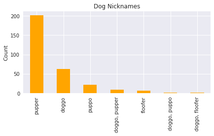

First of all, do names matter? Looking at the above chart we can see that pupper is a favorite nickname for the dogs in this data set. Another interesting little tidbit is that only 38% of retweets contained a dog’s name, meaning familiarity with the dog isn’t a likely factor when a person feels the urge to retweet. But who could deny sharing such cuteness?! When we look at retweets over a week, we can see that engagement was higher on Wednesday and Saturday than the rest of the days of the week. This shows that better times to post would be Wednesday and Saturday as you're more likely, on average, to get higher engagement and the less favorable day to post (for engagement purposes) is Thursday. Still the variances in engagement are slight so I wouldn't base my whole strategy around just that. So all in all, post when you want; you'll likely have higher engagment on Saturday and Wednesday, familiarity isn't necessarily a key to higher engagement, and try to get that buy-in with those favorites, because you're more likely to get a retweet with a higher favorite count.

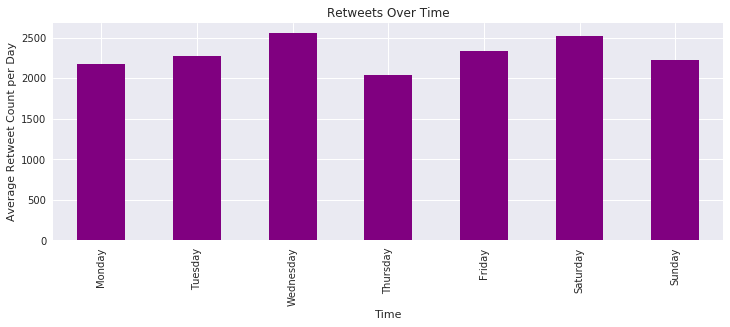